# Project 1

Dani Saunders

2023-09-22

#### **Processing & Reviewing the Data**

The first step is to read in the data. From there it’s good to review the different metadata about the imported dataset.

```r
data <-read.csv('activity/activity.csv')
dim(data)
```

```
## [1] 17568     3
```

```r
head(data)
```

```
##   steps       date interval
## 1    NA 2012-10-01        0
## 2    NA 2012-10-01        5
## 3    NA 2012-10-01       10
## 4    NA 2012-10-01       15
## 5    NA 2012-10-01       20
## 6    NA 2012-10-01       25
```

```r
summary(data)
```

```
##      steps            date              interval
##  Min.   :  0.00   Length:17568       Min.   :   0.0
##  1st Qu.:  0.00   Class :character   1st Qu.: 588.8
##  Median :  0.00   Mode  :character   Median :1177.5
##  Mean   : 37.38                      Mean   :1177.5
##  3rd Qu.: 12.00                      3rd Qu.:1766.2
##  Max.   :806.00                      Max.   :2355.0
##  NA's   :2304
```

#### **What is mean total number of steps taken per day?**

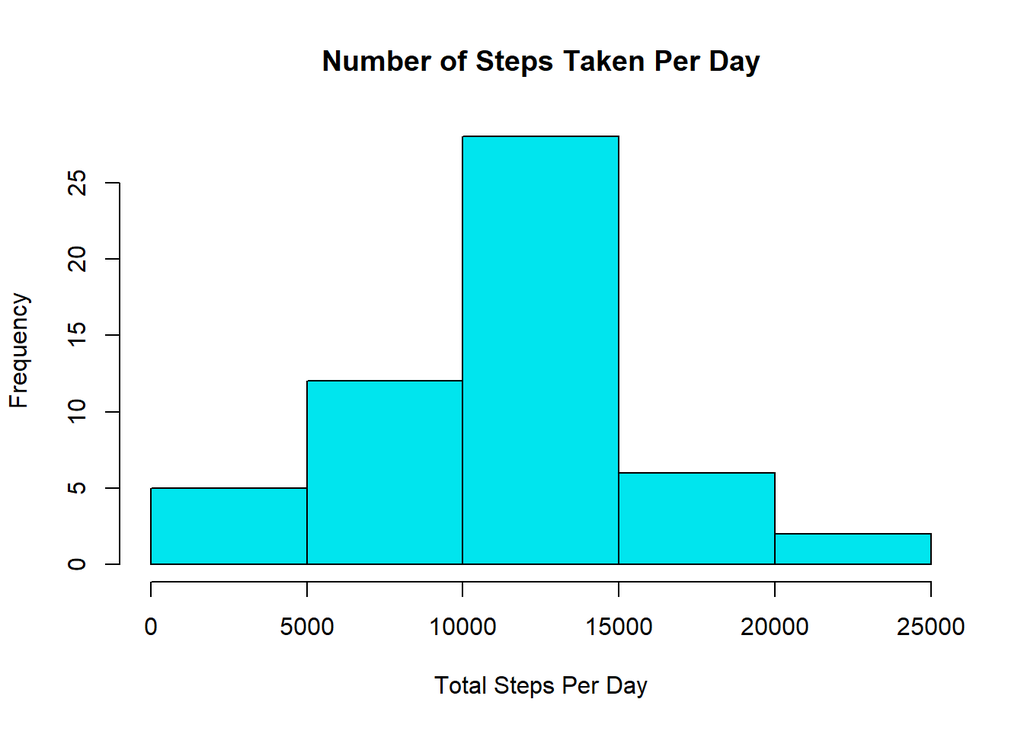

```r
total_steps<-aggregate(x=data$steps,
                       by=list(date=data$date),
                       FUN=sum)
hist(x=total_steps$x,
     xlab='Total Steps Per Day',
     main='Number of Steps Taken Per Day',
     col='turquoise2')
```

The median number of steps is *10765* and the mean number of steps is *10766.19*.

#### **What is the average daily activity pattern?**

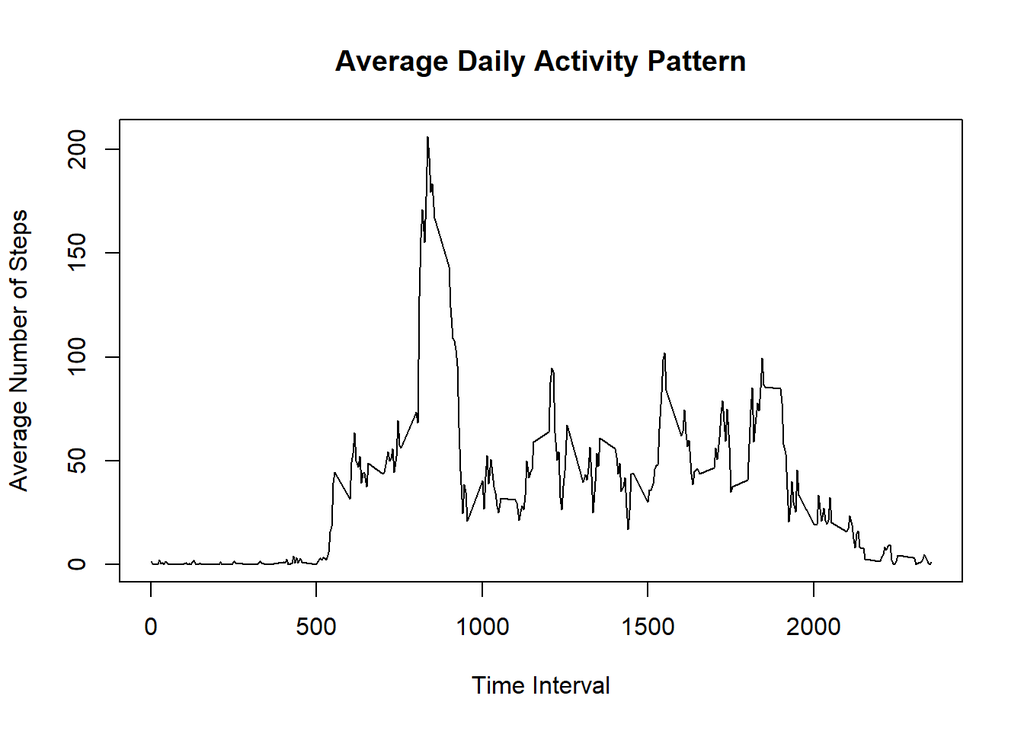

```r
interval_steps<-aggregate(x=list(steps=data$steps),
                          by=list(interval=data$interval),
                          FUN=mean,
                          na.rm=TRUE)
plot(x=interval_steps$interval,
     y=interval_steps$steps,
     type = "l",
     xlab='Time Interval',
     ylab='Average Number of Steps',
     main='Average Daily Activity Pattern')
```

```r
max<-max(interval_steps$steps)
interval_max<-subset(interval_steps, steps==max)
```

The interval with the maximum number of steps is *835*.

### **Imputing missing values**

First, we need to look at dates and intervals that contain any missing value.

```r
missing<-subset(data, is.na(data$steps)==TRUE)

days_missing<-length(unique(missing$date))
intervals_missing<-length(unique(missing$interval))
obs_missing<-length(missing$interval)

days_allmissing<-subset(total_steps, is.na(total_steps$x))
alldays_missing<-length(unique(days_allmissing$date))

interval_sums<-aggregate(x=list(steps=data$steps),
                          by=list(interval=data$interval),
                          FUN=sum,
                          na.rm=TRUE)
intervals_allmissing<-subset(interval_sums, is.na(interval_sums$steps))
allinterval_missing<-length(unique(intervals_allmissing$interval))
```

Based on this information:

- Number of Dates with **any** missing values = *8*
- Number of Dates with **all** missing values = *8*
- Number of Intervals with **any** missing values = *288*
- Number of Intervals with **all** missing values = *0*
- Number of observations with missing values = *2304*

Based on this information, the mean interval values will be used to impute missing values.

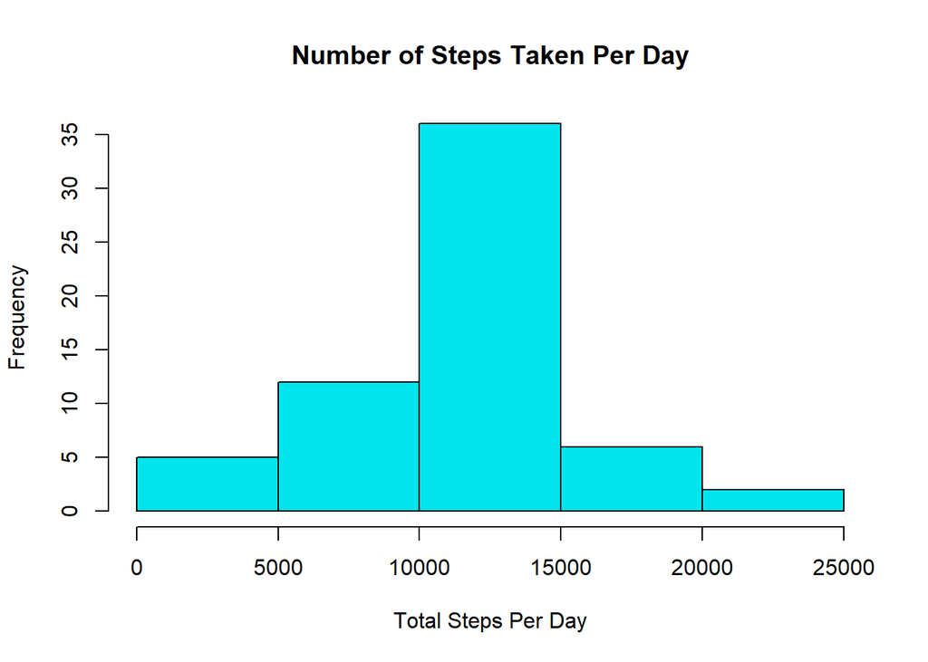

```r
dates_intervals <-merge(x=missing, y=interval_steps, by.x='interval', by.y='interval')
dates_intervals$steps <- round(dates_intervals$steps.y, digits=0)

missing_updated<-dates_intervals[,c('interval','date','steps')]
non_missing<-subset(data,is.na(data$steps)==FALSE)

data_updated<-rbind(missing_updated,non_missing)

total_steps_imputed<-aggregate(x=data_updated$steps,
                              by=list(date=data_updated$date),
                              FUN=sum,
                              na.action=TRUE)
hist(x=total_steps_imputed$x,
     xlab='Total Steps Per Day',
     main='Number of Steps Taken Per Day',
     col='turquoise2')
```

The median number of steps for the imputed dataset is *10763*. The difference between the original data and imputed data is *2*

The mean number of steps for the imputed dataset is *10766.64*. The difference between the original data and imputed data is *-0.450665*

### Are there differences in activity patterns between weekdays and weekends?

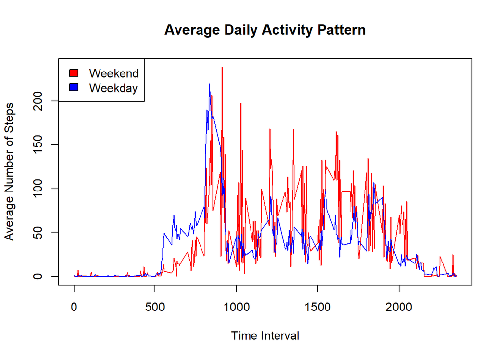

```r
data_updated$date<-as.Date(data_updated$date,'%Y-%m-%d')

data_updated <- cbind(data_updated, Day_Type=weekdays(data_updated$date))

data_updated2 <- cbind(data_updated, Day_Category= ifelse(data_updated$Day_Type ==c("Saturday", "Sunday"),'Weekend','Weekday'))

interval_days<-aggregate(formula=steps ~ interval + Day_Category, data=data_updated2, FUN=mean)

weekend<-subset(interval_days, Day_Category=='Weekend')
weekday<-subset(interval_days, Day_Category=='Weekday')

plot(x=interval_days$interval,
     y=interval_days$steps,
     type = "n",
     xlab='Time Interval',
     ylab='Average Number of Steps',
     main='Average Daily Activity Pattern')
lines(x=weekend$interval, y=weekend$steps, type='l', col='red')
lines(x=weekday$interval, y=weekday$steps, type='l', col='blue')
legend("topleft", legend=c('Weekend','Weekday'),col=c('red','turquoise2'), fill = c('red','blue'))
```

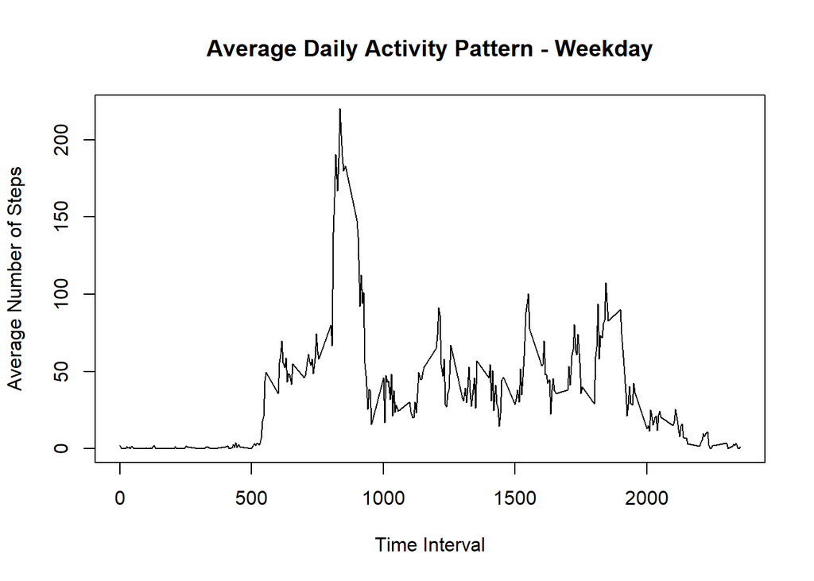

```r
plot(x=weekday$interval,
     y=weekday$steps,
     type = "l",
     xlab='Time Interval',
     ylab='Average Number of Steps',
     main='Average Daily Activity Pattern - Weekday')
```

[figure not shown]

```r
plot(x=weekend$interval,
     y=weekend$steps,
     type = "l",
     xlab='Time Interval',
     ylab='Average Number of Steps',
     main='Average Daily Activity Pattern - Weekday')
```